# 4th Floor Fantast Draft 2016

Evan Oman

September 20, 2016

## Data Preparation

First we load in the spreadsheet Jacob used to record the draft:

```r
library("reshape2")
library("plyr")

draftData <- read.csv("./Draft.csv")
print.data.frame(head(draftData), row.names=FALSE)
```

```
##  ROUND          Mikey          Joey             Jacob           Kuuuby
##      1  Carson Palmer Antonio Brown Odell Beckham Jr.  Adrian Peterson
##      2   Jimmy Graham David Johnson  Brandon Marshall   Julian Edelman
##      3    Mark Ingram    Cam Newton      Lamar Miller Ricardo Lockette
##      4  Jeremy Maclin  Amari Cooper        Greg Olsen       Drew Brees
##      5     Eddie Lacy   Jordan Reed        Matt Forte     LeSean McCoy
##      6 DeSean Jackson    John Brown      Jordy Nelson Demaryius Thomas
##         Andrew            Evan            Will          Chris
##  Aaron Rodgers     Julio Jones     Todd Gurley Allen Robinson
##    T.Y. Hilton Ezekiel Elliott      A.J. Green Rob Gronkowski
##    Golden Tate      Mike Evans    Le'Veon Bell   Randall Cobb
##  Antonio Gates  Russell Wilson DeAndre Hopkins  Brandin Cooks
##   Ryan Mathews Devonta Freeman Latavius Murray  Sammy Watkins
##   Arian Foster    Coby Fleener  Alshon Jeffery   Thomas Rawls
```

As you can see, the data is organized by round with a column for each drafter. This format is often refered to as a “wide dataset.” For this analysis we want a “tall dataset” so we will use the “melt” fundtion to reorganize the data into one row per datapoint (ie one row per pick).

```r
# Melt the data
draftData <- melt(draftData, id.vars = "ROUND")

# Drop the row names
rownames(draftData) <- NULL

# Order by round (this is a stable sort)
draftData <- draftData[order(draftData$ROUND), ]

# Rename some columns
draftData <- rename(draftData, c("variable" = "Drafter", "value" = "Player", "ROUND" = "Round"))

print.data.frame(head(draftData, n=10), row.names=FALSE)
```

```
##  Round Drafter            Player
##      1   Mikey     Carson Palmer
##      1    Joey     Antonio Brown
##      1   Jacob Odell Beckham Jr.
##      1  Kuuuby   Adrian Peterson
##      1  Andrew     Aaron Rodgers
##      1    Evan       Julio Jones
##      1    Will       Todd Gurley
##      1   Chris    Allen Robinson
##      2   Mikey      Jimmy Graham
##      2    Joey     David Johnson
```

Now that we have the data in a tall form, we want to know what the actual number for each pick. This is complicated by the wining nature of the draft order (Chris had the 8th and 9th picks). To capture this behavior I have written the following “snake function” which creates a sequence which winds up to 8 and then counts down from 16, up to 24, etc.

```r
# Creates the sequence: 1,2,3,4,5,6,7,8,16,15,14,13,12,11,10,9,17,18,19,20....
snakeFunction <- function(n, rowLen=8)
{
  lapply(1:n, function(i){
    groupIndicator <- ceiling(i / rowLen)
    # Increasing group
    if (groupIndicator %% 2 == 1)
    {
      i
    }
    # Decreasing group
    else
    {
      rowLen*groupIndicator - ((i - 1) %% rowLen)
    }
  })
}

# Create the list for out draft (8 drafters, 16 rounds)
pickOrdering <- snakeFunction(8*16)

unlist(pickOrdering)
```

```
##   [1]   1   2   3   4   5   6   7   8  16  15  14  13  12  11  10   9  17
##  [18]  18  19  20  21  22  23  24  32  31  30  29  28  27  26  25  33  34
##  [35]  35  36  37  38  39  40  48  47  46  45  44  43  42  41  49  50  51
##  [52]  52  53  54  55  56  64  63  62  61  60  59  58  57  65  66  67  68
##  [69]  69  70  71  72  80  79  78  77  76  75  74  73  81  82  83  84  85
##  [86]  86  87  88  96  95  94  93  92  91  90  89  97  98  99 100 101 102
## [103] 103 104 112 111 110 109 108 107 106 105 113 114 115 116 117 118 119
## [120] 120 128 127 126 125 124 123 122 121
```

We can then use this pick ordering list to index the draft picks in our draft data frame.

```r
# Add the pick numbers to the draft data
draftData$PickNumber <- pickOrdering
draftData <- as.data.frame(lapply(draftData, unlist))

# Order the draft data by pick number
draftData <- draftData[order(draftData$PickNumber),]

print.data.frame(head(draftData, n=10), row.names=FALSE)
```

```
##  Round Drafter            Player PickNumber
##      1   Mikey     Carson Palmer          1
##      1    Joey     Antonio Brown          2
##      1   Jacob Odell Beckham Jr.          3
##      1  Kuuuby   Adrian Peterson          4
##      1  Andrew     Aaron Rodgers          5
##      1    Evan       Julio Jones          6
##      1    Will       Todd Gurley          7
##      1   Chris    Allen Robinson          8
##      2   Chris    Rob Gronkowski          9
##      2    Will        A.J. Green         10
```

Now that the draft data has been prepped, we can load in ESPN rankings (from espn.com)

```r
espn <- read.csv("./ESPN_Rankings.csv")

print.data.frame(head(espn, n=10), row.names=FALSE)
```

```
##  Rank            Player Pos Team Bye Pos.Rk
##     1     Antonio Brown  WR  PIT   8    WR1
##     2 Odell Beckham Jr.  WR  NYG   8    WR2
##     3   Adrian Peterson  RB  MIN   6    RB1
##     4       Julio Jones  WR  ATL  11    WR3
##     5       Todd Gurley  RB   LA   8    RB2
##     6   Ezekiel Elliott  RB  DAL   7    RB3
##     7   DeAndre Hopkins  WR  HOU   9    WR4
##     8     David Johnson  RB  ARI   9    RB4
##     9   Devonta Freeman  RB  ATL  11    RB5
##    10        A.J. Green  WR  CIN   9    WR5
```

This data set is already in the format we want so we can go ahead and join it with our draft data with a match by Player. Note that this is a left join by default so the resulting dataframe will only contain rows from our draft dataframe. Some players will have will not have an ESPN ranking. After the join these players will have a `NA` rank, we will replace this with the worst possible ranking (`nrow(espn)`) plus `1`.

```r
# Join espn rankings data with draft data
joinedData <- join(draftData, espn, by="Player")

# Some players will not have an ESPN ranking, give these players a worst ranking + 1
joinedData$Rank[is.na(joinedData$Rank)] <- nrow(espn) + 1

print.data.frame(head(joinedData, n=10), row.names=FALSE)
```

```
##  Round Drafter            Player PickNumber Rank Pos Team Bye Pos.Rk
##      1   Mikey     Carson Palmer          1   78  QB  ARI   9    QB7
##      1    Joey     Antonio Brown          2    1  WR  PIT   8    WR1
##      1   Jacob Odell Beckham Jr.          3    2  WR  NYG   8    WR2
##      1  Kuuuby   Adrian Peterson          4    3  RB  MIN   6    RB1
##      1  Andrew     Aaron Rodgers          5   49  QB   GB   4    QB2
##      1    Evan       Julio Jones          6    4  WR  ATL  11    WR3
##      1    Will       Todd Gurley          7    5  RB   LA   8    RB2
##      1   Chris    Allen Robinson          8   13  WR  JAC   5    WR6
##      2   Chris    Rob Gronkowski          9   11  TE   NE   9    TE1
##      2    Will        A.J. Green         10   10  WR  CIN   9    WR5
```

We now have a dataframe with each draft pick and the corresponding pick number and player ranking. We can use the pick number and player ranking to measure the quality of each draft pick.

```r
joinedData$RankDiff <- joinedData$PickNumber - joinedData$Rank

print.data.frame(head(joinedData, n=10), row.names=FALSE)
```

```
##  Round Drafter            Player PickNumber Rank Pos Team Bye Pos.Rk
##      1   Mikey     Carson Palmer          1   78  QB  ARI   9    QB7
##      1    Joey     Antonio Brown          2    1  WR  PIT   8    WR1
##      1   Jacob Odell Beckham Jr.          3    2  WR  NYG   8    WR2
##      1  Kuuuby   Adrian Peterson          4    3  RB  MIN   6    RB1
##      1  Andrew     Aaron Rodgers          5   49  QB   GB   4    QB2
##      1    Evan       Julio Jones          6    4  WR  ATL  11    WR3
##      1    Will       Todd Gurley          7    5  RB   LA   8    RB2
##      1   Chris    Allen Robinson          8   13  WR  JAC   5    WR6
##      2   Chris    Rob Gronkowski          9   11  TE   NE   9    TE1
##      2    Will        A.J. Green         10   10  WR  CIN   9    WR5
##  RankDiff
##       -77
##         1
##         1
##         1
##       -44
##         2
##         2
##        -5
##        -2
##         0
```

At this point all of the data has been prepped so we are ready to generate some plots and do a bit of analysis.

## Figures and Results

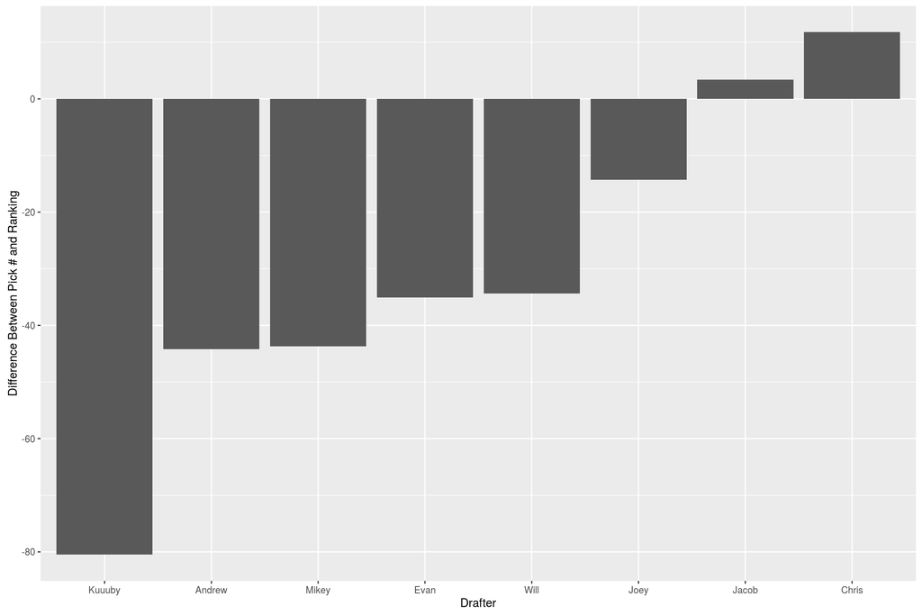

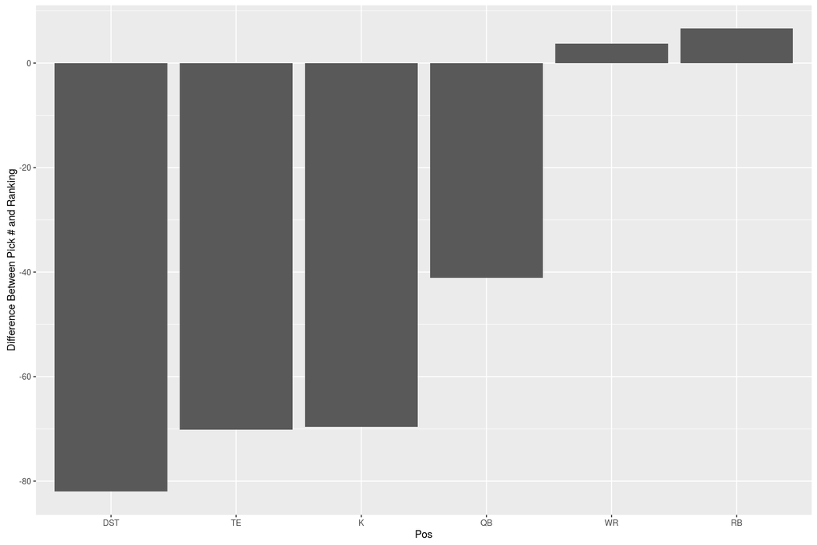

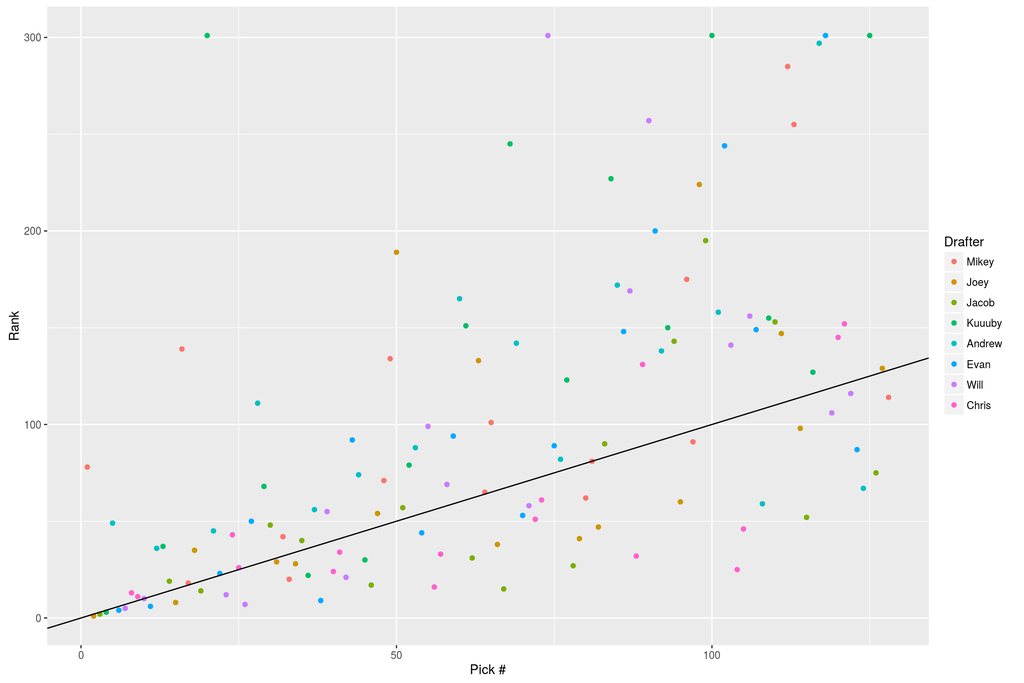

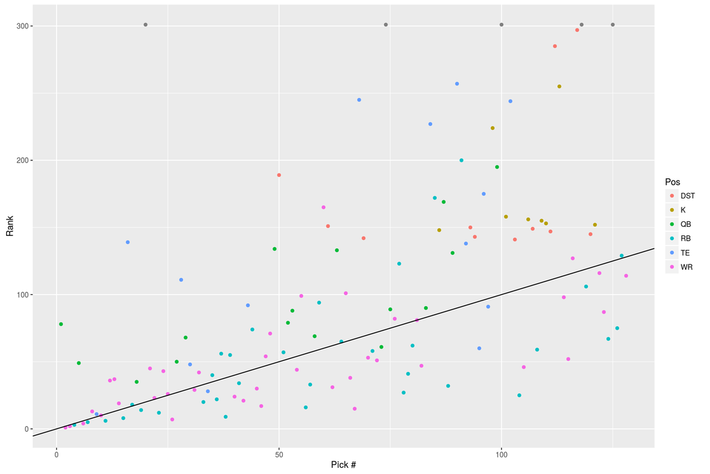

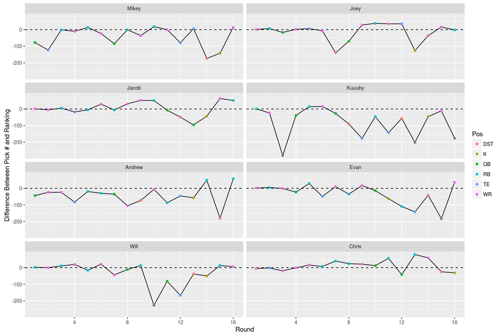